# EMBL tRNA-seq

Aaron Brooks and Daniel Schraivogel

September 30, 2016

Results from tRNA-seq at EMBL. For comparison with CRAC-seq by Tomasz Turowski. Quantification performed by transcript-level quantification with Salmon.

## Figure 1: Class distribution of mapped reads

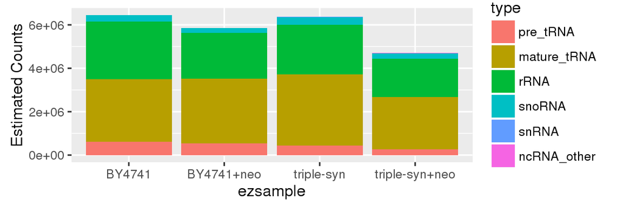

## Figure 2: Class distribution of mapped reads, TPM

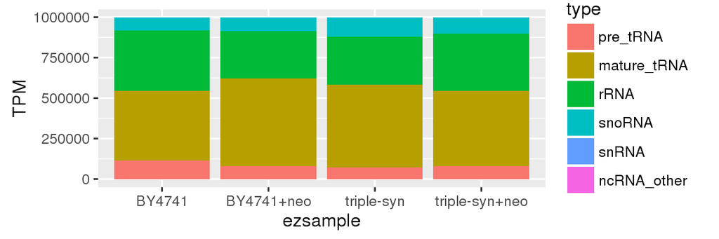

| type | ezsample | TPM | frac |
| --- | --- | --- | --- |
| pre_tRNA | BY4741 | 112513.33 | 0.1125134 |
| pre_tRNA | BY4741+neo | 79454.11 | 0.0794541 |
| mature_tRNA | BY4741 | 431061.93 | 0.4310620 |
| mature_tRNA | BY4741+neo | 541357.98 | 0.5413579 |

## Figure 3: Relative expression of all pre-tRNAs, barplot

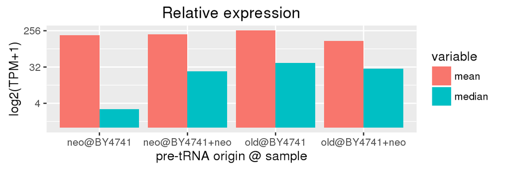

It’s clear from this plot that our data has high variance. Thus the mean and median values give different estimates.

In general, I think it is better to represent these data as a box plot. Since there are so many tRNA species, this gives a better sense for the underlying distribution.

## Figure 4: Relative expression of all pre-tRNAs, boxplot

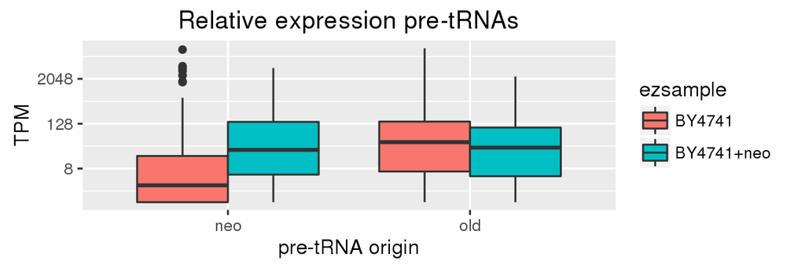

## Figure 5: Relative expression of all pre-tRNAs, by chromosome

A per chromosome view of variation in pre-tRNA levels. Only the **neo** chromosome shows clear difference.

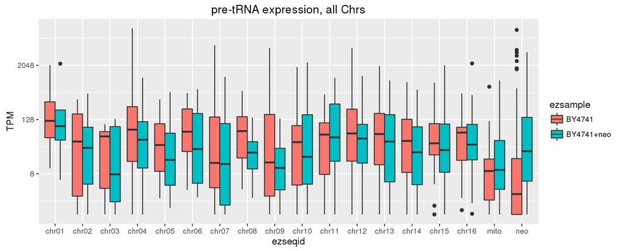

## Figure 6: Relative expression of all **mature-tRNAs**

Roy asked whether the mature tRNA pool is different between the two samples or whether the mature pool adjusts to chr dosage. Our results would suggest *no difference* in mature tRNA pools.

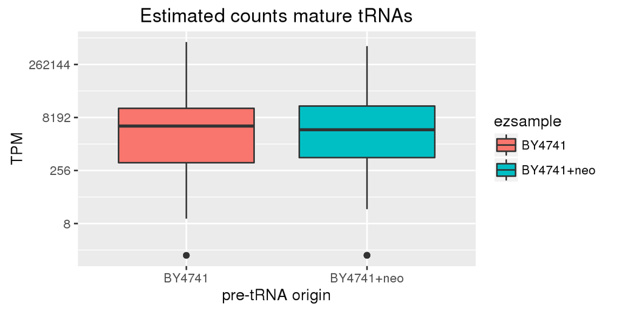

This is substantiated by a simple t-test

```
##
##  Welch Two Sample t-test
##
## data:  by4741_neo and by4741
## t = 0.70939, df = 170, p-value = 0.2395
## alternative hypothesis: true difference in means is greater than 0
## 95 percent confidence interval:
##  -1707.51      Inf
## sample estimates:
## mean of x mean of y
##  6294.860  5012.348
```

## Figure 7: Relative expression of all **mature-tRNAs**, by amino acid

Additionally, when considered on a per amino acid basis, there is little evidence for changes in the mature tRNA pool.

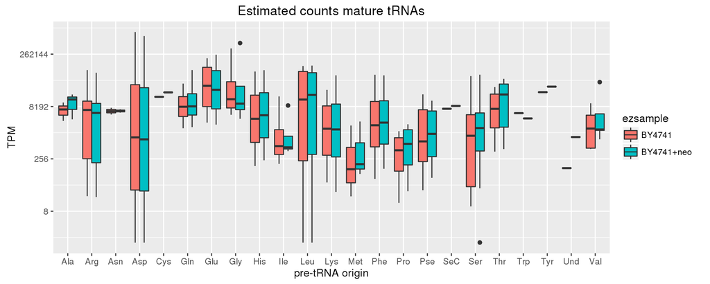

## Figure 8: Relative expression of all **pre-tRNAs** grouped by sample and genomic origin

When considering paired expression of all tRNAs across samples, we do not see the clean separation on the neochr like Tomasz. I think this is the result of lower overall coverage of tRNAs in our dataset. This significantly skews TPM, which are dominated by rRNAs and snoRNAs (see above).

Additionally, there is higher variance in the abundance estimates in our samples. Our data suggest that pre-tRNA abundances are more variable than in CRAC-seq.

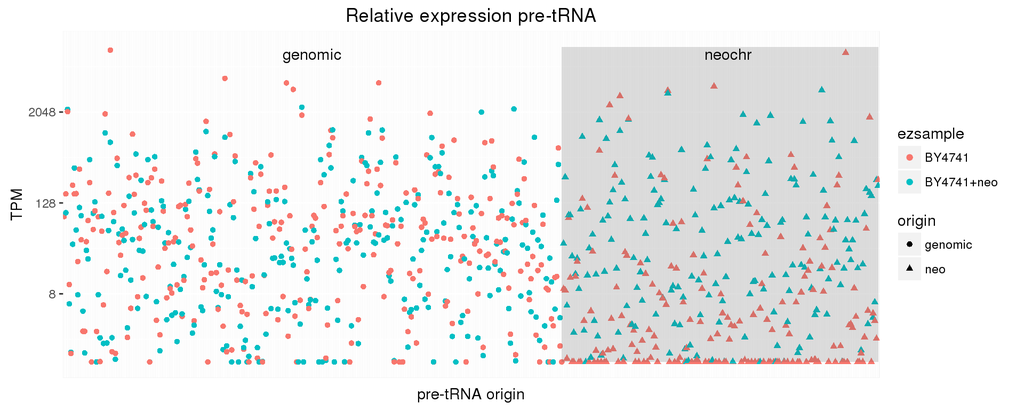

## Figure 9: Absolute estimated expression of all **pre-tRNAs** grouped by sample and genomic origin

The separation of quantifications on the neochr is more evident when using estimated counts. Overall, there does seem to be qualitative agreement between the two methods. However, pre-tRNAs are much less abundant in our dataset.

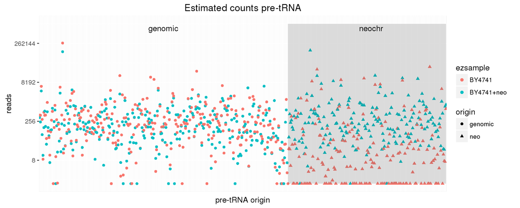